# Lab 3: School Districting

In this lab, we will investigate school districting.

Through this lab, we aim to gain insights into the complex decision-making involved in the creation and optimization of school districts, considering various socio-demographic factors and logistical considerations!

For Lab 3, submit your **HTML** to **CANVAS** :)

```python
import geopandas as gpd
import matplotlib.pyplot as plt
import gurobipy as gp
from gurobipy import GRB
import numpy as np

from shapely.geometry import LineString
import matplotlib.lines as mlines
import pandas as pd
pd.set_option('display.max_rows', 500)

import folium
from folium import plugins
```

```python
import geopandas as gpd
from shapely.geometry import Point, Polygon, MultiPoint
from matplotlib_scalebar.scalebar import ScaleBar
```

## Step 1: Data Preparation

```python
# Import the blocks.shp and hope.shp in the Data folder!

# blocks.shp contains the blocks in the census tracts which intersects with the Hope Elementary School District
blocks = gpd.read_file("Lab3Data/blocks.shp")

# hope.shp contains one geometry of the Hope Elementary School district
hope = gpd.read_file("Lab3Data/hope.shp")
```

#### Question 1. Plot both the blocks GeoDataFrame and the hope GeoDataFrame in a single figure. ( 1 pt )

*Hint: They wouldn't be aligned together automatically!*

**Grading Rubric**

- Ensure that hope is on top of blocks ( +0.5 )
- Ensure that hope has distinguishable edgecolor, but no facecolor ( +0.5 )

```python
blocks.crs
```

```
<Geographic 2D CRS: EPSG:4269>
Name: NAD83
Axis Info [ellipsoidal]:
- Lat[north]: Geodetic latitude (degree)
- Lon[east]: Geodetic longitude (degree)
Area of Use:
- name: North America - onshore and offshore: Canada - Alberta; British Columbia; Manitoba; New Brunswick; Newfoundland and Labrador; Northwest Territories; Nova Scotia; Nunavut; Ontario; Prince Edward Island; Quebec; Saskatchewan; Yukon. Puerto Rico. United States (USA) - Alabama; Alaska; Arizona; …
- bounds: (167.65, 14.92, -40.73, 86.45)
Datum: North American Datum 1983
- Ellipsoid: GRS 1980
- Prime Meridian: Greenwich
```

```python
hope.crs
```

```
<Projected CRS: EPSG:3857>
Name: WGS 84 / Pseudo-Mercator
Axis Info [cartesian]:
- X[east]: Easting (metre)
- Y[north]: Northing (metre)
Area of Use:
- name: World between 85.06°S and 85.06°N.
- bounds: (-180.0, -85.06, 180.0, 85.06)
Coordinate Operation:
- name: Popular Visualisation Pseudo-Mercator
- method: Popular Visualisation Pseudo Mercator
Datum: World Geodetic System 1984 ensemble
- Ellipsoid: WGS 84
- Prime Meridian: Greenwich
```

```python
hope_shape = gpd.GeoDataFrame(geometry=[hope.to_crs(blocks.crs).unary_union], crs=blocks.crs)
hope_shape
```

|  | geometry |
| --- | --- |
| 0 | POLYGON ((-119.73041 34.47950, -119.73057 34.4... |

```
<matplotlib_scalebar.scalebar.ScaleBar at 0x12ef72a90>
```

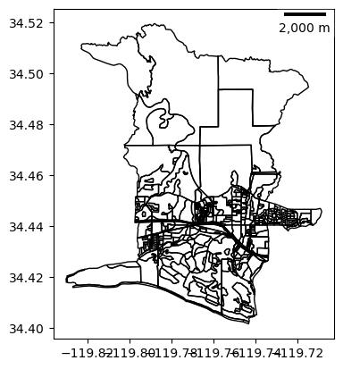

```python
A = blocks.plot(color="none", zorder=100, markersize=10)
hope_shape.plot(ax=A, facecolor='None', edgecolor="black", zorder=100)

scalebar = ScaleBar(dx=1, scale_formatter=lambda data, unit: f'{data},000 m', length_fraction=0.25, units = 'm')
A.add_artist(scalebar)
```

#### Question 2. Plot the "elpop" column of the blocks DataFrame, which represents the elementary student population of each block. ( 1 pt )

**Grading Rubric**

- Title and Legend are provided, legend is numeric ( +0.5 )
- Scalebar and Axis information is provided ( +0.5 )

**Note:** Only 5-9 years old children population in the block is included in the dataset.  
As decennial census provides the age ranges 5-9, 10-14, 14-19 and so on.  
Refer to this webpage to learn more. https://api.census.gov/data/2020/dec/dhc/variables.html  
Also, you can refer to dataprep.ipynb file to see how the lab data is prepared!

```python
len(blocks)
```

```
448
```

```
<matplotlib_scalebar.scalebar.ScaleBar at 0x12c518150>
```

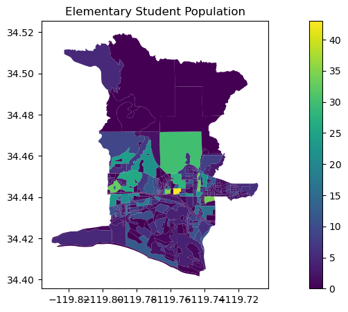

```python
ax = blocks.plot("elpop", legend=True, figsize=(15,5))

plt.title("Elementary Student Population")
scalebar = ScaleBar(dx=1, scale_formatter=lambda data, unit: f'{data},000 m', length_fraction=0.25, units = 'm')
A.add_artist(scalebar)
```

#### Question 3: Subset the blocks GeoDataFrame to include only the blocks within the Hope Elementary School District, and assign this subset to the variable named "blocks". ( 1 pt )

*So.. you are updating the existing variable, "blocks"*

*Hint:* Visualize the output of the blocks GeoDataFrame by plotting it alongside the hope GeoDataFrame to verify if all the blocks within the Hope School District have been included.

If some blocks are missing, you can ensure you have all the necessary blocks by cross-referencing the spatial extent of the blocks GeoDataFrame with the boundaries of the Hope School District defined in the hope GeoDataFrame.  
Ensure that the spatial query used to subset the blocks properly captures all the relevant blocks within the district's boundaries.

**NOTE: Every time taking a subset, don't forget to "RESET_INDEX()" !!**

```python
blocks = blocks.to_crs(hope.crs)
```

```python
blocks = blocks.loc[blocks.within(hope.unary_union.buffer(20))].reset_index()
```

```python
# Ensure to print this out, so I can grade!
len(blocks)
```

```
202
```

#### Question 4: Calculate the total elementary student population within the Hope Elementary School District. ( 1 pt )

```python
blocks["elpop"].sum()
```

```
832
```

#### Question 5: Find the fraction of white-only students among the total elementary student population within the Hope Elementary School District. ( 1 pt )

```python
blocks["elwpop"].sum()
```

```
419
```

#### Question 6: Create a new variable, "schools", containing only the schools managed by the Hope Elementary School District. ( 2 pts )

**Steps:**

1. Download the California school point location shapefile from this data source (https://gis.data.ca.gov/datasets/f7f818b0aa7a415192eaf66f192bc9cc/explore)
2. Locate the file in Data folder and read the shapefile in this notebook
3. Take a subset of the file by only including schools within the hope GeoDataFrame ( +1 )
4. Take another subset, which only includes school that are part of Hope Elementary School district. Assign the subset to a variable, "schools" ( +1 )

**NOTE: Every time taking a subset, don't forget to "RESET_INDEX()" !!**

*Hint*  
Look into this webpage. (https://www.hopeschooldistrict.org/en-US/schools)  
Hope Elementary school district only includes three elementary schools.  
Make sure that your schools GeoDataFrame includes only the three elementary schools

```python
schoolsite = gpd.read_file("Lab3Data/SchoolSites1920.shp")
```

```python
sb_schoolsite = schoolsite.loc[schoolsite["CountyName"].isin(["Santa Barbara"])]
```

```python
schools = sb_schoolsite.loc[sb_schoolsite["DistrictNa"].isin(["Hope Elementary"])]
```

```python
# Run this cell to print out your schools
schools
```

|  | Year | FedID | CDSCode | CDCode | SCode | CountyName | DistrictNa | SchoolName | SchoolType | Status | ... | HOMpct | MIGcount | MIGpct | SEDCount | SEDpct | SWDcount | SWDpct | FRPMcount | FRPMpct | geometry |
| --- | --- | --- | --- | --- | --- | --- | --- | --- | --- | --- | --- | --- | --- | --- | --- | --- | --- | --- | --- | --- | --- |
| 8241 | 2019-20 | 061749007426 | 42692116045538 | 4269211 | 6045538 | Santa Barbara | Hope Elementary | Hope Elementary | Elementary | Active | ... | 1.0 | 0 | 0.0 | 116 | 37.5 | 39 | 12.6 | 111 | 35.9 | POINT (-13330987.696 4088677.224) |
| 8242 | 2019-20 | 061749002189 | 42692116045546 | 4269211 | 6045546 | Santa Barbara | Hope Elementary | Monte Vista Elementary | Elementary | Active | ... | 0.3 | 0 | 0.0 | 77 | 25.2 | 28 | 9.2 | 77 | 25.2 | POINT (-13330040.367 4089457.472) |
| 8243 | 2019-20 | 061749002190 | 42692116045553 | 4269211 | 6045553 | Santa Barbara | Hope Elementary | Vieja Valley Elementary | Elementary | Active | ... | 0.0 | 0 | 0.0 | 99 | 31.1 | 23 | 7.2 | 97 | 30.5 | POINT (-13332674.187 4087471.860) |

3 rows × 68 columns

```
(-13334911.302039243,
 -13327952.754065603,
 4082794.1911112475,
 4095880.496022277)
```

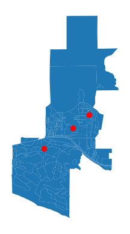

```python
# Run this cell to map your schools
A = blocks.plot()
schools.plot(ax=A, color="red")
plt.axis("off")
```

## Step 2: Optimization Model Preparation

> This section is to prepare the known information needed for our optimization model, and set parameters.

```python
# Tolerance is about how much you'd like to allow each school to deviate from the ideal capacity, which is the total number of students / the number of schools
TOLERANCE = 1.2 # 1.2 will allow schools to deviate by 20 %
```

#### Task: Set the I, J value correctly.

Things to consider.

- I is the total number of blocks
- J is the total number of schools

```python
I = len(blocks)
J = len(schools)
```

#### Task: Prepare $S_i$ and $N_i$ variables for the model.

$S_i$ must be an array of the elementary student population at each block  
$N_i$ must be an array of the elementary student population in minority race at each block

```python
S_i = blocks["elpop"]
N_i = blocks["elpop"] - blocks["elwpop"]
```

#### Task: Prepare $C_j$ variable for the model.

$C_j$ indicates that it's an array. In that case, different capacity constraint is assigned to each school.  
However, for our convenience, let's do integer capacity this time.  
As we will set $C_j$ variable as an integer, let's use a notation, $C$.  
The $C$ integer value will be calculated by following steps.

1. The total elementary student population across the blocks
2. Divided by the number of schools (which is equal to J)
3. Multiplied by TOLERANCE

```python
C = (sum(S_i) / J)*TOLERANCE
```

```python
schools = schools.reset_index(drop=True)
```

#### Question 7: Prepare $D_{ij}$ variable for the model. ( 2 pts )

$D_{ij}$ represents a two-dimensional array with two subscripts, $i$ and $j$.

Considerations:

- The first subscript $i$ denotes the row index in the two-dimensional array, corresponding to a block with index $i$.
- The second subscript $j$ denotes the column index in the two-dimensional array, representing a school with index $j$.
  - For instance, if we have 100 blocks and 10 schools, $D_{ij}$ would be a two-dimensional array (or matrix) of shape (100, 10), consisting of 100 rows and 10 columns.
  - Consequently, $D_{ji}$ would be a matrix of shape (10, 100), containing 10 rows and 100 columns.
- $D_{ij}$ denotes that given a row index $i$ and column index $j$, a specific value can be retrieved, which represents the distance between the $i$th block and the $j$th school.
  - For example, $D_{12}$ would indicate the distance between the second block and the third school.

Given that, let's create the $D_ij$ variable.

```python
D_ij = [[np.sqrt((blocks.geometry.centroid.x[i] - schools.geometry.x[j])**2 + (blocks.geometry.centroid.y[i] - schools.geometry.y[j])**2)
         for j in range (J)] for i in range (I)]
```

```python
# Check the shape of your two-dimensional array, D_ij.
# It must match (I, J)

np.array(D_ij).shape, (I,J)
```

```
((202, 3), (202, 3))
```

#### Question 8: Choose upper and lower thresholds for the minority race fraction at each school and provide reasoning for your selection. ( 2 pts )

```python
FN_high = 0.7
FN_low = 0.3
```

## Step 3: Optimization ( Wei et al., 2021 )

The model presented in the paper:

\begin{align*} \text{minimize} \quad & \sum_{i=1}^{I} \sum_{j=1}^{J} D_{ij} \cdot S_i \cdot x_{ij} \\ \text{subject to} \quad & \sum_{j=1}^{J} x_{ij} = 1 \quad \text{for } i = 1, \ldots, I \\ & \sum_{i=1}^{I} x_{ij} \cdot S_i \leq C_j \quad \text{for } j = 1, \ldots, J \\ & \sum_{i=1}^{I} (FN_{\text{low}} \cdot S_i - N_i) \cdot x_{ij} \leq 0 \quad \text{for } j = 1, \ldots, J \\ & \sum_{i=1}^{I} (N_i - FN_{\text{high}} \cdot S_i) \cdot x_{ij} \leq 0 \quad \text{for } j = 1, \ldots, J \\ & x_{ij} \in \{0,1\} \quad \text{for } i = 1, \ldots, I \text{ and } j = 1, \ldots, J \end{align*}

#### Question 9: Construct the School Districting Optimization Model using the provided skeleton code structure. ( 5 pts )

```python
model = gp.Model("School Districts")

# Create decision variables
x = model.addVars(I, J, vtype=GRB.BINARY, name="x")

# Set objective
model.setObjective(gp.quicksum(gp.quicksum(x[i,j] * S_i[i] * D_ij[i][j] for j in range (J)) for i in range (I)), GRB.MINIMIZE)

# Add constraints
# Constraint 1
model.addConstrs(gp.quicksum(x[i,j] for j in range(J)) == 1 for i in range(I))
# Constraint 2
model.addConstrs(gp.quicksum(x[i,j]* S_i[i] for i in range(I)) <= C for j in range(J))
# Constraint 3
model.addConstrs(gp.quicksum(x[i,j]* (FN_low * S_i[i] - N_i[i]) for i in range(I)) <= 0 for j in range(J))
# Constraint 4
model.addConstrs(gp.quicksum(x[i,j]* (N_i[i] - FN_high * S_i[i]) for i in range(I)) <= 0 for j in range(J))

# Optimize model
model.optimize()
```

```
Restricted license - for non-production use only - expires 2025-11-24
Gurobi Optimizer version 11.0.1 build v11.0.1rc0 (mac64[x86] - Darwin 22.5.0 22F66)

CPU model: Intel(R) Core(TM) i3-1000NG4 CPU @ 1.10GHz
Thread count: 2 physical cores, 4 logical processors, using up to 4 threads

Optimize a model with 211 rows, 606 columns and 1737 nonzeros
Model fingerprint: 0x0dd14e22
Variable types: 0 continuous, 606 integer (606 binary)
Coefficient statistics:
  Matrix range     [1e-01, 4e+01]
  Objective range  [2e+02, 1e+05]
  Bounds range     [1e+00, 1e+00]
  RHS range        [1e+00, 3e+02]
Found heuristic solution: objective 1710126.9847
Presolve removed 76 rows and 228 columns
Presolve time: 0.01s
Presolved: 135 rows, 378 columns, 1509 nonzeros
Variable types: 0 continuous, 378 integer (378 binary)
Found heuristic solution: objective 1014050.3837

Root relaxation: objective 8.282846e+05, 129 iterations, 0.00 seconds (0.00 work units)

    Nodes    |    Current Node    |     Objective Bounds      |     Work
 Expl Unexpl |  Obj  Depth IntInf | Incumbent    BestBd   Gap | It/Node Time

*    0     0               0    828284.59253 828284.593  0.00%     -    0s

Explored 1 nodes (129 simplex iterations) in 0.16 seconds (0.00 work units)
Thread count was 4 (of 4 available processors)

Solution count 3: 828285 1.01405e+06 1.71013e+06

Optimal solution found (tolerance 1.00e-04)
Best objective 8.282845925344e+05, best bound 8.282845925344e+05, gap 0.0000%
```

## Step 4: Application Result Visualization

Let's say.. We want to know what is the index of the largest value, 100, in list_a.  
We can convert list_a into np.array and use .argmax() to find the index!  
Then it returns the index of value, 100 in list_a, which is 7.  
It means it's 8th element. Do you agree?

```python
list_a = [1,2,3,4,5,6,7,100]
np.array(list_a).argmax()
```

```
7
```

#### Task: Use the argmax() function to find out which school index j, each block i is assigned to.

```python
# For hint, let's print out what values decision variables x have.
# Check if model solved it correctly.
    # Are all blocks assigned to only one school?
# If model solved it correctly, for each row in x matrix, finding the argmax will give the index of assigned school for each block.

for i in range(I):
    print(f"block {i}:", end=" ")
    for j in range(J):
        print(x[i,j].x, end=" ")
    print()
```

```
block 0: 1.0 0.0 0.0
block 1: 1.0 0.0 0.0
block 2: 1.0 -0.0 -0.0
block 3: -0.0 -0.0 1.0
block 4: 1.0 0.0 0.0
block 5: 1.0 0.0 0.0
block 6: 1.0 0.0 0.0
block 7: -0.0 1.0 -0.0
block 8: 1.0 0.0 0.0
block 9: -0.0 -0.0 1.0
block 10: -0.0 -0.0 1.0
block 11: -0.0 1.0 -0.0
block 12: -0.0 -0.0 1.0
block 13: 1.0 0.0 0.0
block 14: -0.0 -0.0 1.0
block 15: -0.0 -0.0 1.0
block 16: -0.0 1.0 -0.0
block 17: -0.0 -0.0 1.0
block 18: 1.0 -0.0 -0.0
block 19: 1.0 0.0 0.0
block 20: 1.0 0.0 0.0
block 21: 1.0 0.0 0.0
block 22: 1.0 0.0 0.0
block 23: 1.0 0.0 0.0
block 24: -0.0 -0.0 1.0
block 25: 1.0 -0.0 -0.0
block 26: -0.0 -0.0 1.0
block 27: 1.0 0.0 0.0
block 28: 1.0 -0.0 -0.0
block 29: 1.0 0.0 0.0
block 30: -0.0 1.0 -0.0
block 31: 1.0 0.0 0.0
block 32: 1.0 0.0 0.0
block 33: -0.0 1.0 -0.0
block 34: -0.0 1.0 -0.0
block 35: -0.0 -0.0 1.0
block 36: 1.0 0.0 0.0
block 37: -0.0 1.0 -0.0
block 38: -0.0 -0.0 1.0
block 39: 1.0 0.0 0.0
```

[output cut: 147 more lines]

```
block 187: -0.0 -0.0 1.0
block 188: 1.0 -0.0 -0.0
block 189: -0.0 -0.0 1.0
block 190: 1.0 0.0 0.0
block 191: -0.0 -0.0 1.0
block 192: -0.0 -0.0 1.0
block 193: -0.0 1.0 -0.0
block 194: -0.0 1.0 -0.0
block 195: -0.0 -0.0 1.0
block 196: 1.0 0.0 0.0
block 197: -0.0 -0.0 1.0
block 198: 1.0 0.0 0.0
block 199: 1.0 0.0 0.0
block 200: 1.0 0.0 0.0
block 201: -0.0 -0.0 1.0
```

```python
# Initialize an empty array to store the assigned school for each block.
assigned_school = []

# Iterate through each block
for i in range(I):  # Loop through each block index, i
    # Determine the school assignment for the current block i based on the optimization model solution.
    assigned_school.append(np.array([x[i,j].x for j in range(J)]).argmax())
        # Find the index (j) of the maximum value for each block i, indicating the assigned school.
        ###############PUT YOUR ANSWER HERE###############


# Create a new column in the blocks GeoDataFrame to indicate the assigned school for each block.
blocks["assigned_school"] = assigned_school
```

```python
# Start an empty array, to store the linestring connecting each block centroid to the assigned school
lines = []

# Iterate through each block, i
for i in range(I):
    j = assigned_school[i] # get the assigned school index, j
    lines.append(LineString([blocks.centroid[i], schools.geometry[j]])) # Create a LineString with two points, ith block centroid and jth school
                                                                        # And append it to lines array.
```

```python
# Create a GeoDataFrame wtih the lines geometry,
# and add a column, "assigned_pop" with the number of students in each block.
line_pop = gpd.GeoDataFrame({"assigned_pop": S_i, "assigned_school": assigned_school}, geometry=lines)
```

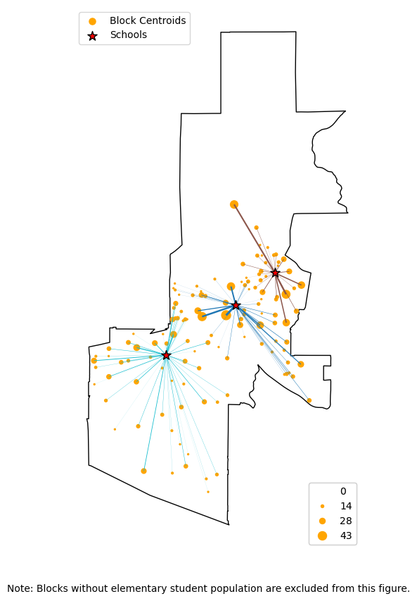

```python
# Plot the hope GeoDataFrame
A = hope.plot(facecolor="None", figsize=(10, 10))  # Plot the hope_ GeoSeries with specified facecolor and figure size

# Plot centroids of blocks with markersize proportional to elpop
blocks.centroid.plot(ax=A, markersize=blocks.elpop * 2, color="orange", label="Block Centroids")  # Plot centroids of blocks with markersize proportional to elpop, and assign a label for the legend

# Plot line_pop with linewidth proportional to assigned_pop
line_pop.plot("assigned_school", ax=A, linewidth=line_pop.assigned_pop / 20, categorical=True)  # Plot line_pop with linewidth proportional to assigned_pop

# Plot schools with custom marker style
schools.plot(ax=A, label="Schools", color="red", markersize=100, marker="*", zorder=100, edgecolor="black")  # Plot schools with custom marker style and assign a label for the legend

# Turn off axis
plt.axis("off")  # Turn off the axis for the plot

# Add legend for the plotted elements
plt.legend(loc=2)  # Add legend for the plotted elements with location specified

# Note to users about excluded blocks without elementary student population
plt.text(0.5, 0.05, "Note: Blocks without elementary student population are excluded from this figure.", ha='center', fontsize=10, transform=plt.gcf().transFigure)  # Add a note to the plot regarding excluded blocks

leg1 = A.get_legend()  # Get the legend for the first set of plotted elements

# Define bins for the legend indicating size
_, bins = pd.cut(blocks["elpop"], bins=3, precision=0, retbins=True)  # Define bins for the legend indicating size based on elpop values

# Create second legend indicating size
A.add_artist(
    A.legend(
        handles=[
            mlines.Line2D(
                [],
                [],
                color="orange",
                lw=0,
                marker="o",
                markersize=b / 5,
                label=str(int(b)),
            )
            for i, b in enumerate(bins)
        ],
        loc=4,
    )
)

# Restore the original legend
A.add_artist(leg1)

# Show the plot
plt.show()
```

#### Task: Convert the Coordiante System of the GeoDataFrames to 4326

This time, we will do figure with folium, to create an interactive map.  
For folium, all geographic datasets must be in crs with EPSG code: 4326. (https://epsg.io/4326)  
Let's convert all GeoDataFrames into the 4326 crs.

```python
line_pop.crs = "EPSG:4326"
```

```python
blocks_4326 = blocks.to_crs(epsg=4326)
hope_4326 = hope.to_crs(epsg=4326)
schools_4326 = schools.to_crs(epsg=4326)
line_pop_4326 = line_pop.to_crs(epsg=4326)
```

```python
# Create a Folium Map object with specified location, tiles, zoom level, and scale control
m = folium.Map(location=[blocks_4326.unary_union.centroid.y, blocks_4326.unary_union.centroid.x], tiles="Cartodb Positron", zoom_start=15, control_scale=True)

# Convert GeoDataFrame to GeoJSON
hope_geojson = hope_4326.to_json()

# Add GeoJSON layer for hope_ with specified name and tooltip, and style function to control appearance
folium.GeoJson(
    hope_geojson,
    name='Hope Elementary School District',
    tooltip='Hope Elementary School District',
    style_function=lambda x: {'color': 'black', 'fillColor': 'None', 'weight': 1}
).add_to(m)


# Add markers for centroids of blocks
for idx, row in blocks_4326.loc[blocks_4326.elpop>0].iterrows():
    # Create circle markers for centroids of blocks with popup information
    folium.CircleMarker(
        location=[row.geometry.centroid.y, row.geometry.centroid.x],
        radius=row.elpop/2,  # Adjust the factor to control marker size
        popup=f"Block ID: {row.GEOID20}, <br><br> ElPop: {row.elpop} <br><br> AssignedTo: {schools.SchoolName[row.assigned_school]}",
        fill=True,
        color='orange',
        fill_opacity=0.6,
        fill_color='orange'
    ).add_to(m)

# Add markers for schools
for idx, row in schools_4326.iterrows():
    folium.Marker(
        location=[row.geometry.y, row.geometry.x],
        popup=f"{row.SchoolName}",
    ).add_to(m)

# Helper function to generate style function with specified color
def style_function(color):
    return lambda x: {
        'color': color,
        'weight': x['properties']['assigned_pop'] / 10,
    }

# Add line_pop as a GeoJSON layer with specified name and style function
for j in range(J):
    if j == 0:
        color = "blue"
    elif j == 1:
        color = "brown"
    else:
        color = "skyblue"

    line_pop_geojson = line_pop_4326.loc[line_pop_4326.assigned_school == j].reset_index(drop=True).to_json()
    folium.GeoJson(
        line_pop_geojson,
        name=f'line_pop_{j}',
        style_function=style_function(color)  # Use the helper function to generate the style function
    ).add_to(m)

# Display the map
m  # This line displays the map
```

Make this Notebook Trusted to load map: File -> Trust Notebook

[interactive chart not shown]

## Step 5: Result Evaluation

```python
# Let's gather current districting information

curr_hope = gpd.read_file("Lab3Data/digitized_current_districts.shp")
curr_dist_school_map = {0:2, 1:0, 2:1}

curr_assigned = []

for block in blocks.geometry:
    max_inter_dist_index = block.intersection(curr_hope.geometry).area.argmax()
    cur_assgined_school_j = curr_dist_school_map[max_inter_dist_index]
    curr_assigned.append(cur_assgined_school_j)

blocks["curr_assigned"] = curr_assigned
```

```python
def evaluate_assignment(col = "curr_assigned"):
    popsums = []
    FNs = []
    Travel_ds = []
    for j in range(J):
        school_blocks = blocks.loc[blocks[col]==j]
        popsum = school_blocks.elpop.sum()
        wsum = school_blocks.elwpop.sum()
        FNs.append((1 - wsum/popsum)*100)
        popsums.append(popsum)

        Travel_d = 0
        for i in school_blocks.index:
            Travel_d += D_ij[i][j] * S_i[i]
        Travel_ds.append(Travel_d / popsum)
    print(f"Mean Travel Distance (m) is {np.mean(Travel_ds)}")
    return pd.DataFrame({'School':schools.SchoolName, 'Capacity':popsums, 'FN':FNs, "Travel_ds (m)": Travel_ds})


evaluate_assignment("curr_assigned").round(2)
```

```
Mean Travel Distance (m) is 1188.6860737315344
```

|  | School | Capacity | FN | Travel_ds (m) |
| --- | --- | --- | --- | --- |
| 0 | Hope Elementary | 166 | 51.20 | 1105.63 |
| 1 | Monte Vista Elementary | 295 | 47.46 | 892.49 |
| 2 | Vieja Valley Elementary | 371 | 50.67 | 1567.93 |

```python
evaluate_assignment(col = "assigned_school").round(2)
```

```
Mean Travel Distance (m) is 990.5946246120551
```

|  | School | Capacity | FN | Travel_ds (m) |
| --- | --- | --- | --- | --- |
| 0 | Hope Elementary | 325 | 63.69 | 920.37 |
| 1 | Monte Vista Elementary | 233 | 31.33 | 803.00 |
| 2 | Vieja Valley Elementary | 274 | 48.54 | 1248.42 |

```python
# Import the random module for generating random numbers
import random

# Set the seed to ensure reproducibility of random numbers
random.seed(1)

# Generate random assignments for each block to one of the three schools
blocks["assigned_random"] = random.choices(range(3), k=len(blocks))

# Evaluate the random assignment and display the results, rounding to two decimal places
evaluate_assignment(col="assigned_random").round(2)
```

```
Mean Travel Distance (m) is 2040.0482193543814
```

|  | School | Capacity | FN | Travel_ds (m) |
| --- | --- | --- | --- | --- |
| 0 | Hope Elementary | 206 | 45.63 | 1807.02 |
| 1 | Monte Vista Elementary | 296 | 46.96 | 2050.87 |
| 2 | Vieja Valley Elementary | 330 | 54.55 | 2262.26 |

#### Question 10: Share insights gleaned from the analysis of the school districting process. Feel free to discuss with Step 6 result. ( 2 pts )

You can discuss about..

- Minority Fraction bounds
- Capacity constraints
- Distance metric
- and so on!

**Write your answer in this markdown cell!**

Based on the data, we can tell that here are tradeoffs when it comes to satisfying different requirements. In the current assignment, there is a decent proportion of minority fraction however, there are significantly different student capacities as well as travel distances. Random assignment somewhat balances diversity, but it also drastically increases mean travel distances and causes an imbalance in student capacity. The evaluated assignment decreases the mean travel distance, however when looking closely, the lowest and highest capacities and travel distances are very different which seems unfair to many.

## Step 6. Network Distance Utilization

In this section, network distance will be utilized in the optimization procedure instead of Euclidean distance.  
**You will be asked to copy and paste the code from the previous steps to the designated location.**  
The Origin-Destination matrix can be found in the file "driving_od_matrix.csv", and the geometry for each path is provided in "routes.shp".

```python
# Read the driving origin-destination (OD) matrix from a CSV file
od = pd.read_csv("Lab3Data/driving_od_matrix.csv")

# Initialize a matrix D_ij to store driving distances between each block and each school
D_ij = np.ones((len(blocks), len(schools))) * -1

# Populate the D_ij matrix with driving distances from the OD matrix
for o in range(len(od)):
    # Extract the origin and destination IDs from the OD matrix
    i, j = od.loc[o, ["OriginID", "DestinationID"]]
    # Store the driving distance in meters in the corresponding cell of D_ij matrix
    D_ij[i - 1][j - 1] = od.loc[o, "Total_Kilometers"] * 1000

# Check if all elements of the D_ij matrix are non-negative, indicating valid driving distances
(D_ij >= 0).sum() == len(blocks) * len(schools)
```

```
False
```

```python
# Copy and Paste your optimization model above!

model = gp.Model("School Districts")

# Create decision variables
x = model.addVars(I, J, vtype=GRB.BINARY, name="x")

# Set objective
model.setObjective(gp.quicksum(gp.quicksum(x[i,j] * S_i[i] * D_ij[i][j] for j in range (J)) for i in range (I)), GRB.MINIMIZE)

# Add constraints
# Constraint 1
model.addConstrs(gp.quicksum(x[i,j] for j in range(J)) == 1 for i in range(I))
# Constraint 2
model.addConstrs(gp.quicksum(x[i,j]* S_i[i] for i in range(I)) <= C for j in range(J))
# Constraint 3
model.addConstrs(gp.quicksum(x[i,j]* (FN_low * S_i[i] - N_i[i]) for i in range(I)) <= 0 for j in range(J))
# Constraint 4
model.addConstrs(gp.quicksum(x[i,j]* (N_i[i] - FN_high * S_i[i]) for i in range(I)) <= 0 for j in range(J))

# Optimize model
model.optimize()
```

```
Gurobi Optimizer version 11.0.1 build v11.0.1rc0 (mac64[x86] - Darwin 22.5.0 22F66)

CPU model: Intel(R) Core(TM) i3-1000NG4 CPU @ 1.10GHz
Thread count: 2 physical cores, 4 logical processors, using up to 4 threads

Optimize a model with 211 rows, 606 columns and 1737 nonzeros
Model fingerprint: 0x9c2c3a1a
Variable types: 0 continuous, 606 integer (606 binary)
Coefficient statistics:
  Matrix range     [1e-01, 4e+01]
  Objective range  [2e+00, 2e+05]
  Bounds range     [1e+00, 1e+00]
  RHS range        [1e+00, 3e+02]
Found heuristic solution: objective 2270029.6582
Presolve removed 76 rows and 228 columns
Presolve time: 0.01s
Presolved: 135 rows, 378 columns, 1509 nonzeros
Variable types: 0 continuous, 378 integer (378 binary)
Found heuristic solution: objective 1502604.6523

Root relaxation: objective 1.300277e+06, 126 iterations, 0.00 seconds (0.00 work units)

    Nodes    |    Current Node    |     Objective Bounds      |     Work
 Expl Unexpl |  Obj  Depth IntInf | Incumbent    BestBd   Gap | It/Node Time

*    0     0               0    1300276.8803 1300276.88  0.00%     -    0s

Explored 1 nodes (126 simplex iterations) in 0.03 seconds (0.00 work units)
Thread count was 4 (of 4 available processors)

Solution count 3: 1.30028e+06 1.5026e+06 2.27003e+06

Optimal solution found (tolerance 1.00e-04)
Best objective 1.300276880255e+06, best bound 1.300276880255e+06, gap 0.0000%
```

```python
# Initialize an empty array to store the assigned school for each block.
assigned_school = []

# Iterate through each block
for i in range(I):  # Loop through each block index, i
    # Determine the school assignment for the current block i based on the optimization model solution.
    assigned_school.append(np.array([x[i,j].x for j in range(J)]).argmax())
        # Find the index (j) of the maximum value for each block i, indicating the assigned school.
        ###########YOUR ANSWER HERE#############

# Create a new column in the blocks GeoDataFrame to indicate the assigned school for each block.
blocks["assigned_driving"] = assigned_school
```

```python
evaluate_assignment("curr_assigned").round(2)
```

```
Mean Travel Distance (m) is 2052.763102146973
```

|  | School | Capacity | FN | Travel_ds (m) |
| --- | --- | --- | --- | --- |
| 0 | Hope Elementary | 166 | 51.20 | 1500.41 |
| 1 | Monte Vista Elementary | 295 | 47.46 | 2169.19 |
| 2 | Vieja Valley Elementary | 371 | 50.67 | 2488.69 |

```python
evaluate_assignment(col = "assigned_driving").round(2)
```

```
Mean Travel Distance (m) is 1554.3549208817349
```

|  | School | Capacity | FN | Travel_ds (m) |
| --- | --- | --- | --- | --- |
| 0 | Hope Elementary | 284 | 63.38 | 1573.73 |
| 1 | Monte Vista Elementary | 262 | 35.50 | 1258.84 |
| 2 | Vieja Valley Elementary | 286 | 48.95 | 1830.49 |

Try two different ways of assignment representation in the following cell!

- OPTION 1: is to represent the assignment with straight line.
- OPTION 2: is to represent the assignment with road network route.

```python
### OPTION 1: Straight Line
# lines = []
# for i in range(I):
#     j = assigned_school[i]
#     lines.append(LineString([blocks.centroid[i], schools.geometry[j]]))


### OPTION 2: Route
routes = gpd.read_file("Lab3Data/driving_routes.shp").to_crs(3857)
routes.Name = routes.Name.astype("int")
lines = []
for i in range(I):
    j = assigned_school[i]
    lines.append(routes.loc[routes.Name == j*201 + i, "geometry"].values[0])
```

```python
line_pop = gpd.GeoDataFrame({"assigned_pop": S_i, "assigned_school": assigned_school}, geometry=lines)
```

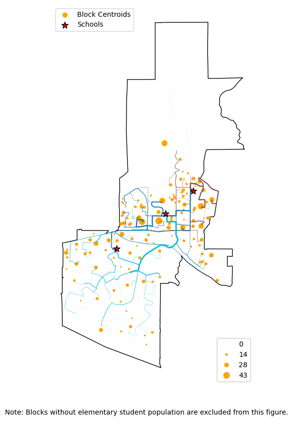

```python
import matplotlib.pyplot as plt  # Import the matplotlib library for plotting

# Plot the hope_ GeoSeries
A = hope.plot(facecolor="None", figsize=(10, 10))  # Plot the hope_ GeoSeries with specified facecolor and figure size

# Plot centroids of blocks with markersize proportional to elpop
blocks.centroid.plot(ax=A, markersize=blocks.elpop * 2, color="orange", label="Block Centroids")  # Plot centroids of blocks with markersize proportional to elpop, and assign a label for the legend

# Plot line_pop with linewidth proportional to assigned_pop
line_pop.plot("assigned_school", ax=A, linewidth=line_pop.assigned_pop / 20, categorical=True)  # Plot line_pop with linewidth proportional to assigned_pop

# Plot schools with custom marker style
schools.plot(ax=A, label="Schools", color="red", markersize=100, marker="*", zorder=100, edgecolor="black")  # Plot schools with custom marker style and assign a label for the legend

# Turn off axis
plt.axis("off")  # Turn off the axis for the plot

# Add legend for the plotted elements
plt.legend(loc=2)  # Add legend for the plotted elements with location specified

# Note to users about excluded blocks without elementary student population
plt.text(0.5, 0.05, "Note: Blocks without elementary student population are excluded from this figure.", ha='center', fontsize=10, transform=plt.gcf().transFigure)  # Add a note to the plot regarding excluded blocks

leg1 = A.get_legend()  # Get the legend for the first set of plotted elements

# Define bins for the legend indicating size
_, bins = pd.cut(blocks["elpop"], bins=3, precision=0, retbins=True)  # Define bins for the legend indicating size based on elpop values

# Create second legend indicating size
A.add_artist(
    A.legend(
        handles=[
            mlines.Line2D(
                [],
                [],
                color="orange",
                lw=0,
                marker="o",
                markersize=b / 5,
                label=str(int(b)),
            )
            for i, b in enumerate(bins)
        ],
        loc=4,
    )
)

# Restore the original legend
A.add_artist(leg1)

# Show the plot
plt.show()
```

```python
# Convert the GeoDataFrame into 4326 crs!
line_pop.crs = "EPSG:4326"
line_pop_4326 = line_pop.to_crs(epsg=4326)

blocks_4326 = blocks.to_crs(epsg=4326)
hope_4326 = hope.to_crs(epsg=4326)
schools_4326 = schools.to_crs(epsg=4326)
line_pop_4326 = line_pop.to_crs(epsg=4326)

# Create a Folium Map object with specified location, tiles, zoom level, and scale control
m = folium.Map(location=[blocks_4326.unary_union.centroid.y, blocks_4326.unary_union.centroid.x], tiles="Cartodb Positron", zoom_start=15, control_scale=True)

# Convert GeoDataFrame to GeoJSON
hope_geojson = hope_4326.to_json()

# Add GeoJSON layer for hope_ with specified name and tooltip, and style function to control appearance
folium.GeoJson(
    hope_geojson,
    name='Hope Elementary School District',
    tooltip='Hope Elementary School District',
    style_function=lambda x: {'color': 'black', 'fillColor': 'None', 'weight': 1}
).add_to(m)


# Add markers for centroids of blocks
for idx, row in blocks_4326.loc[blocks_4326.elpop>0].iterrows():
    # Create circle markers for centroids of blocks with popup information
    folium.CircleMarker(
        location=[row.geometry.centroid.y, row.geometry.centroid.x],
        radius=row.elpop/2,  # Adjust the factor to control marker size
        popup=f"Block ID: {row.GEOID20}, <br><br> ElPop: {row.elpop} <br><br> AssignedTo: {schools.SchoolName[row.assigned_school]}",
        fill=True,
        color='orange',
        fill_opacity=0.6,
        fill_color='orange'
    ).add_to(m)

# Add markers for schools
for idx, row in schools_4326.iterrows():
    folium.Marker(
        location=[row.geometry.y, row.geometry.x],
        popup=f"{row.SchoolName}",
    ).add_to(m)

# Helper function to generate style function with specified color
def style_function(color):
    return lambda x: {
        'color': color,
        'weight': x['properties']['assigned_pop'] / 10,
    }

# Add line_pop as a GeoJSON layer with specified name and style function
for j in range(J):
    if j == 0:
        color = "blue"
    elif j == 1:
        color = "brown"
    else:
        color = "skyblue"

    line_pop_geojson = line_pop_4326.loc[line_pop_4326.assigned_school == j].reset_index(drop=True).to_json()
    folium.GeoJson(
        line_pop_geojson,
        name=f'line_pop_{j}',
        style_function=style_function(color)  # Use the helper function to generate the style function
    ).add_to(m)

# Display the map
m  # This line displays the map
```

Make this Notebook Trusted to load map: File -> Trust Notebook

[interactive chart not shown]